# Risk Factor Analysis

## Outcome Variable

**Outcome Variable:** stunted

## Predictor Variables

**Intervention Variable:** hhwealth_quart

**Adjustment Set:**

- arm
- sex
- W_mage
- meducyrs
- feducyrs
- W_gagebrth
- W_birthwt
- W_birthlen
- W_nchldlt5
- W_parity
- delta_W_mage
- delta_meducyrs
- delta_feducyrs
- delta_W_gagebrth
- delta_W_birthwt
- delta_W_birthlen
- delta_W_nchldlt5
- delta_W_parity

## Stratifying Variables

The analysis was stratified on these variable(s):

- agecat
- studyid
- country

## Data Summary

| agecat | studyid | country | hhwealth_quart | stunted | n_cell | n |
| --- | --- | --- | --- | --- | --- | --- |
| Birth | CMC-V-BCS-2002 | INDIA | Wealth Q4 | 0 | 24 | 92 |
| Birth | CMC-V-BCS-2002 | INDIA | Wealth Q4 | 1 | 8 | 92 |
| Birth | CMC-V-BCS-2002 | INDIA | Wealth Q1 | 0 | 13 | 92 |
| Birth | CMC-V-BCS-2002 | INDIA | Wealth Q1 | 1 | 2 | 92 |
| Birth | CMC-V-BCS-2002 | INDIA | Wealth Q2 | 0 | 18 | 92 |
| Birth | CMC-V-BCS-2002 | INDIA | Wealth Q2 | 1 | 2 | 92 |
| Birth | CMC-V-BCS-2002 | INDIA | Wealth Q3 | 0 | 20 | 92 |
| Birth | CMC-V-BCS-2002 | INDIA | Wealth Q3 | 1 | 5 | 92 |
| Birth | COHORTS | GUATEMALA | Wealth Q4 | 0 | 278 | 816 |
| Birth | COHORTS | GUATEMALA | Wealth Q4 | 1 | 15 | 816 |
| Birth | COHORTS | GUATEMALA | Wealth Q1 | 0 | 147 | 816 |
| Birth | COHORTS | GUATEMALA | Wealth Q1 | 1 | 10 | 816 |
| Birth | COHORTS | GUATEMALA | Wealth Q2 | 0 | 149 | 816 |
| Birth | COHORTS | GUATEMALA | Wealth Q2 | 1 | 12 | 816 |
| Birth | COHORTS | GUATEMALA | Wealth Q3 | 0 | 195 | 816 |
| Birth | COHORTS | GUATEMALA | Wealth Q3 | 1 | 10 | 816 |
| Birth | COHORTS | PHILIPPINES | Wealth Q4 | 0 | 810 | 3049 |
| Birth | COHORTS | PHILIPPINES | Wealth Q4 | 1 | 32 | 3049 |
| Birth | COHORTS | PHILIPPINES | Wealth Q1 | 0 | 635 | 3049 |
| Birth | COHORTS | PHILIPPINES | Wealth Q1 | 1 | 52 | 3049 |
| Birth | COHORTS | PHILIPPINES | Wealth Q2 | 0 | 500 | 3049 |
| Birth | COHORTS | PHILIPPINES | Wealth Q2 | 1 | 38 | 3049 |
| Birth | COHORTS | PHILIPPINES | Wealth Q3 | 0 | 917 | 3049 |
| Birth | COHORTS | PHILIPPINES | Wealth Q3 | 1 | 65 | 3049 |
| Birth | CONTENT | PERU | Wealth Q4 | 0 | 0 | 2 |
| Birth | CONTENT | PERU | Wealth Q4 | 1 | 0 | 2 |
| Birth | CONTENT | PERU | Wealth Q1 | 0 | 0 | 2 |
| Birth | CONTENT | PERU | Wealth Q1 | 1 | 0 | 2 |
| Birth | CONTENT | PERU | Wealth Q2 | 0 | 1 | 2 |
| Birth | CONTENT | PERU | Wealth Q2 | 1 | 0 | 2 |

[output cut: 386 more lines]

The following strata were considered:

- agecat: 24 months, studyid: CMC-V-BCS-2002, country: INDIA
- agecat: 24 months, studyid: COHORTS, country: GUATEMALA
- agecat: 24 months, studyid: COHORTS, country: PHILIPPINES
- agecat: 24 months, studyid: CONTENT, country: PERU
- agecat: 24 months, studyid: GMS-Nepal, country: NEPAL
- agecat: 24 months, studyid: IRC, country: INDIA
- agecat: 24 months, studyid: JiVitA-3, country: BANGLADESH
- agecat: 24 months, studyid: JiVitA-4, country: BANGLADESH
- agecat: 24 months, studyid: LCNI-5, country: MALAWI
- agecat: 24 months, studyid: MAL-ED, country: BANGLADESH
- agecat: 24 months, studyid: MAL-ED, country: BRAZIL
- agecat: 24 months, studyid: MAL-ED, country: INDIA
- agecat: 24 months, studyid: MAL-ED, country: NEPAL
- agecat: 24 months, studyid: MAL-ED, country: PERU
- agecat: 24 months, studyid: MAL-ED, country: SOUTH AFRICA
- agecat: 24 months, studyid: MAL-ED, country: TANZANIA, UNITED REPUBLIC OF
- agecat: 24 months, studyid: PROVIDE, country: BANGLADESH
- agecat: 24 months, studyid: TanzaniaChild2, country: TANZANIA, UNITED REPUBLIC OF
- agecat: 6 months, studyid: CMC-V-BCS-2002, country: INDIA
- agecat: 6 months, studyid: COHORTS, country: GUATEMALA
- agecat: 6 months, studyid: COHORTS, country: PHILIPPINES
- agecat: 6 months, studyid: CONTENT, country: PERU
- agecat: 6 months, studyid: GMS-Nepal, country: NEPAL
- agecat: 6 months, studyid: IRC, country: INDIA
- agecat: 6 months, studyid: JiVitA-3, country: BANGLADESH
- agecat: 6 months, studyid: JiVitA-4, country: BANGLADESH
- agecat: 6 months, studyid: LCNI-5, country: MALAWI
- agecat: 6 months, studyid: MAL-ED, country: BANGLADESH
- agecat: 6 months, studyid: MAL-ED, country: BRAZIL
- agecat: 6 months, studyid: MAL-ED, country: INDIA
- agecat: 6 months, studyid: MAL-ED, country: NEPAL
- agecat: 6 months, studyid: MAL-ED, country: PERU
- agecat: 6 months, studyid: MAL-ED, country: SOUTH AFRICA
- agecat: 6 months, studyid: MAL-ED, country: TANZANIA, UNITED REPUBLIC OF
- agecat: 6 months, studyid: PROVIDE, country: BANGLADESH
- agecat: 6 months, studyid: TanzaniaChild2, country: TANZANIA, UNITED REPUBLIC OF
- agecat: Birth, studyid: CMC-V-BCS-2002, country: INDIA
- agecat: Birth, studyid: COHORTS, country: GUATEMALA
- agecat: Birth, studyid: COHORTS, country: PHILIPPINES
- agecat: Birth, studyid: CONTENT, country: PERU
- agecat: Birth, studyid: GMS-Nepal, country: NEPAL
- agecat: Birth, studyid: IRC, country: INDIA
- agecat: Birth, studyid: JiVitA-3, country: BANGLADESH
- agecat: Birth, studyid: JiVitA-4, country: BANGLADESH
- agecat: Birth, studyid: MAL-ED, country: BANGLADESH
- agecat: Birth, studyid: MAL-ED, country: BRAZIL
- agecat: Birth, studyid: MAL-ED, country: INDIA
- agecat: Birth, studyid: MAL-ED, country: NEPAL
- agecat: Birth, studyid: MAL-ED, country: PERU
- agecat: Birth, studyid: MAL-ED, country: SOUTH AFRICA
- agecat: Birth, studyid: MAL-ED, country: TANZANIA, UNITED REPUBLIC OF
- agecat: Birth, studyid: PROVIDE, country: BANGLADESH

### Dropped Strata

Some strata were dropped due to rare outcomes:

- agecat: Birth, studyid: CMC-V-BCS-2002, country: INDIA
- agecat: Birth, studyid: CONTENT, country: PERU
- agecat: Birth, studyid: MAL-ED, country: BRAZIL
- agecat: Birth, studyid: MAL-ED, country: INDIA
- agecat: Birth, studyid: MAL-ED, country: NEPAL
- agecat: Birth, studyid: MAL-ED, country: SOUTH AFRICA
- agecat: Birth, studyid: MAL-ED, country: TANZANIA, UNITED REPUBLIC OF
- agecat: Birth, studyid: PROVIDE, country: BANGLADESH
- agecat: 6 months, studyid: CONTENT, country: PERU
- agecat: 6 months, studyid: MAL-ED, country: BRAZIL
- agecat: 6 months, studyid: MAL-ED, country: NEPAL
- agecat: 24 months, studyid: CONTENT, country: PERU
- agecat: 24 months, studyid: MAL-ED, country: BRAZIL
- agecat: 24 months, studyid: TanzaniaChild2, country: TANZANIA, UNITED REPUBLIC OF

## Methods Detail

We’re interested in the causal parameters $E[Y_a]$ for all values of $a \in \mathcal{A}$. These parameters represent the mean outcome if, possibly contrary to fact, we intervened to set all units to have $A=a$. Under the randomization and positivity assumptions, these are identified by the statistical parameters $\psi_a=E_W[E_{Y|A,W}(Y|A=a,W)]$. In addition, we’re interested in the mean of $Y$, $E[Y]$ under no intervention (the observed mean). We will estimate these parameters by using SuperLearner to fit the relevant likelihood factors – $E_{Y|A,W}(Y|A=a,W)$ and $p(A=a|W)$, and then updating our likelihood fit using a joint TMLE.

For unadjusted analyses ($W=\{\}$), initial likelihoods were estimated using Lrnr_glm to estimate the simple $E(Y|A)$ and Lrnr_mean to estimate $p(A)$. For adjusted analyses, a small library containing Lrnr_glmnet, Lrnr_xgboost, and Lrnr_mean was used.

Having estimated these parameters, we will then use the delta method to estimate relative risks and attributable risks relative to a prespecified baseline level of $A$.

# Results Detail

## Results Plots

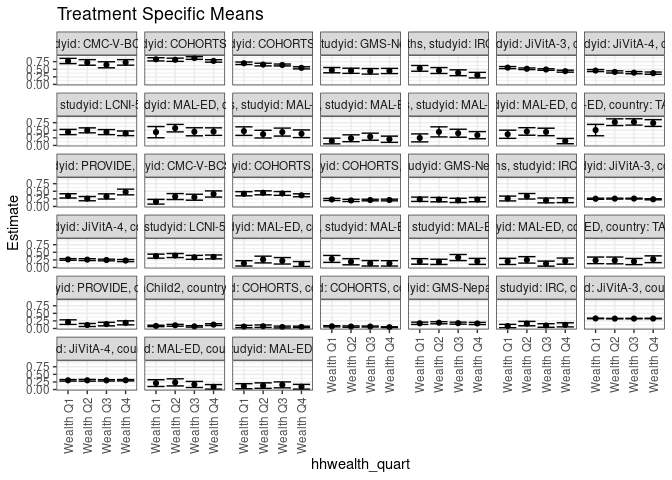

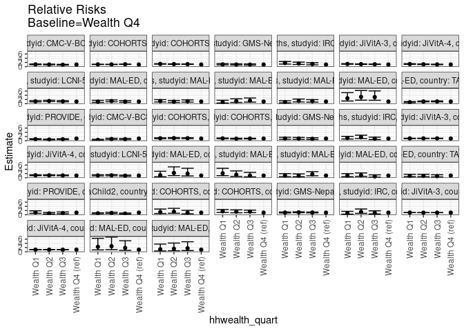

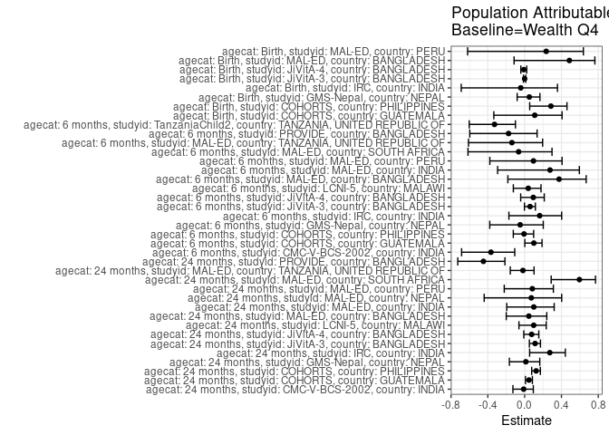

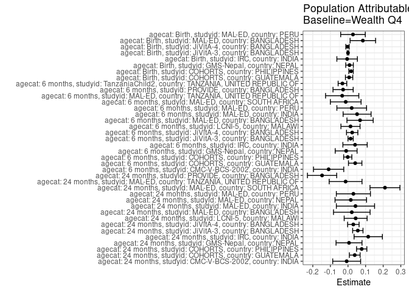

## Results Table

### Parameter: TSM

| agecat | studyid | country | intervention_level | baseline_level | estimate | ci_lower | ci_upper |
| --- | --- | --- | --- | --- | --- | --- | --- |
| Birth | COHORTS | GUATEMALA | Wealth Q4 | NA | 0.0512776 | 0.0260748 | 0.0764803 |
| Birth | COHORTS | GUATEMALA | Wealth Q1 | NA | 0.0639319 | 0.0255949 | 0.1022690 |
| Birth | COHORTS | GUATEMALA | Wealth Q2 | NA | 0.0751873 | 0.0343367 | 0.1160378 |
| Birth | COHORTS | GUATEMALA | Wealth Q3 | NA | 0.0489981 | 0.0192977 | 0.0786986 |
| Birth | COHORTS | PHILIPPINES | Wealth Q4 | NA | 0.0438126 | 0.0302774 | 0.0573478 |
| Birth | COHORTS | PHILIPPINES | Wealth Q1 | NA | 0.0721140 | 0.0526360 | 0.0915920 |
| Birth | COHORTS | PHILIPPINES | Wealth Q2 | NA | 0.0646041 | 0.0429733 | 0.0862348 |
| Birth | COHORTS | PHILIPPINES | Wealth Q3 | NA | 0.0652671 | 0.0494182 | 0.0811160 |
| Birth | GMS-Nepal | NEPAL | Wealth Q4 | NA | 0.1664444 | 0.1312238 | 0.2016650 |
| Birth | GMS-Nepal | NEPAL | Wealth Q1 | NA | 0.1720457 | 0.1346617 | 0.2094297 |
| Birth | GMS-Nepal | NEPAL | Wealth Q2 | NA | 0.1906189 | 0.1564560 | 0.2247819 |
| Birth | GMS-Nepal | NEPAL | Wealth Q3 | NA | 0.1757618 | 0.1425912 | 0.2089324 |
| Birth | IRC | INDIA | Wealth Q4 | NA | 0.1208791 | 0.0538154 | 0.1879429 |
| Birth | IRC | INDIA | Wealth Q1 | NA | 0.0816327 | 0.0273532 | 0.1359121 |
| Birth | IRC | INDIA | Wealth Q2 | NA | 0.1616162 | 0.0890131 | 0.2342192 |
| Birth | IRC | INDIA | Wealth Q3 | NA | 0.1000000 | 0.0411252 | 0.1588748 |
| Birth | JiVitA-3 | BANGLADESH | Wealth Q4 | NA | 0.3290868 | 0.3204744 | 0.3376991 |
| Birth | JiVitA-3 | BANGLADESH | Wealth Q1 | NA | 0.3318688 | 0.3238006 | 0.3399370 |
| Birth | JiVitA-3 | BANGLADESH | Wealth Q2 | NA | 0.3271642 | 0.3195846 | 0.3347439 |
| Birth | JiVitA-3 | BANGLADESH | Wealth Q3 | NA | 0.3279615 | 0.3202203 | 0.3357026 |
| Birth | JiVitA-4 | BANGLADESH | Wealth Q4 | NA | 0.3063060 | 0.2854369 | 0.3271752 |
| Birth | JiVitA-4 | BANGLADESH | Wealth Q1 | NA | 0.3033278 | 0.2788191 | 0.3278366 |
| Birth | JiVitA-4 | BANGLADESH | Wealth Q2 | NA | 0.3034495 | 0.2752381 | 0.3316609 |
| Birth | JiVitA-4 | BANGLADESH | Wealth Q3 | NA | 0.3019292 | 0.2799989 | 0.3238594 |
| Birth | MAL-ED | BANGLADESH | Wealth Q4 | NA | 0.0892857 | 0.0144243 | 0.1641471 |
| Birth | MAL-ED | BANGLADESH | Wealth Q1 | NA | 0.2115385 | 0.1002748 | 0.3228021 |
| Birth | MAL-ED | BANGLADESH | Wealth Q2 | NA | 0.2352941 | 0.1186030 | 0.3519852 |
| Birth | MAL-ED | BANGLADESH | Wealth Q3 | NA | 0.1666667 | 0.0670328 | 0.2663005 |
| Birth | MAL-ED | PERU | Wealth Q4 | NA | 0.0925926 | 0.0151013 | 0.1700839 |
| Birth | MAL-ED | PERU | Wealth Q1 | NA | 0.1090909 | 0.0265080 | 0.1916738 |

[output cut: 122 more lines]

### Parameter: E(Y)

| agecat | studyid | country | intervention_level | baseline_level | estimate | ci_lower | ci_upper |
| --- | --- | --- | --- | --- | --- | --- | --- |
| Birth | COHORTS | GUATEMALA | NA | NA | 0.0575980 | 0.0416028 | 0.0735933 |
| Birth | COHORTS | PHILIPPINES | NA | NA | 0.0613316 | 0.0528136 | 0.0698496 |
| Birth | GMS-Nepal | NEPAL | NA | NA | 0.1752874 | 0.1470202 | 0.2035545 |
| Birth | IRC | INDIA | NA | NA | 0.1159794 | 0.0840777 | 0.1478811 |
| Birth | JiVitA-3 | BANGLADESH | NA | NA | 0.3290987 | 0.3217223 | 0.3364751 |
| Birth | JiVitA-4 | BANGLADESH | NA | NA | 0.3035461 | 0.2835868 | 0.3235054 |
| Birth | MAL-ED | BANGLADESH | NA | NA | 0.1737089 | 0.1227104 | 0.2247075 |
| Birth | MAL-ED | PERU | NA | NA | 0.1209302 | 0.0772464 | 0.1646140 |
| 6 months | CMC-V-BCS-2002 | INDIA | NA | NA | 0.3008130 | 0.2539566 | 0.3476694 |
| 6 months | COHORTS | GUATEMALA | NA | NA | 0.4086486 | 0.3769522 | 0.4403450 |
| 6 months | COHORTS | PHILIPPINES | NA | NA | 0.2112260 | 0.1958496 | 0.2266024 |
| 6 months | GMS-Nepal | NEPAL | NA | NA | 0.2163121 | 0.1823021 | 0.2503220 |
| 6 months | IRC | INDIA | NA | NA | 0.2457002 | 0.2038248 | 0.2875757 |
| 6 months | JiVitA-3 | BANGLADESH | NA | NA | 0.2513837 | 0.2432545 | 0.2595129 |
| 6 months | JiVitA-4 | BANGLADESH | NA | NA | 0.2524352 | 0.2383740 | 0.2664965 |
| 6 months | LCNI-5 | MALAWI | NA | NA | 0.3627451 | 0.3297365 | 0.3957537 |
| 6 months | MAL-ED | BANGLADESH | NA | NA | 0.1833333 | 0.1342773 | 0.2323893 |
| 6 months | MAL-ED | INDIA | NA | NA | 0.1872340 | 0.1372518 | 0.2372162 |
| 6 months | MAL-ED | PERU | NA | NA | 0.2222222 | 0.1725409 | 0.2719036 |
| 6 months | MAL-ED | SOUTH AFRICA | NA | NA | 0.1967871 | 0.1473064 | 0.2462679 |
| 6 months | MAL-ED | TANZANIA, UNITED REPUBLIC OF | NA | NA | 0.2388664 | 0.1855834 | 0.2921494 |
| 6 months | PROVIDE | BANGLADESH | NA | NA | 0.1589404 | 0.1297581 | 0.1881227 |
| 6 months | TanzaniaChild2 | TANZANIA, UNITED REPUBLIC OF | NA | NA | 0.0965347 | 0.0836528 | 0.1094165 |
| 24 months | CMC-V-BCS-2002 | INDIA | NA | NA | 0.7169811 | 0.6710815 | 0.7628807 |
| 24 months | COHORTS | GUATEMALA | NA | NA | 0.8115942 | 0.7877598 | 0.8354286 |
| 24 months | COHORTS | PHILIPPINES | NA | NA | 0.6229039 | 0.6036892 | 0.6421186 |
| 24 months | GMS-Nepal | NEPAL | NA | NA | 0.4487705 | 0.4045970 | 0.4929440 |
| 24 months | IRC | INDIA | NA | NA | 0.4205379 | 0.3726382 | 0.4684376 |
| 24 months | JiVitA-3 | BANGLADESH | NA | NA | 0.4911284 | 0.4780181 | 0.5042387 |
| 24 months | JiVitA-4 | BANGLADESH | NA | NA | 0.4008848 | 0.3839144 | 0.4178552 |
| 24 months | LCNI-5 | MALAWI | NA | NA | 0.4425087 | 0.4018409 | 0.4831765 |
| 24 months | MAL-ED | BANGLADESH | NA | NA | 0.4764151 | 0.4090254 | 0.5438047 |
| 24 months | MAL-ED | INDIA | NA | NA | 0.4273128 | 0.3628178 | 0.4918077 |
| 24 months | MAL-ED | NEPAL | NA | NA | 0.2192982 | 0.1654718 | 0.2731246 |
| 24 months | MAL-ED | PERU | NA | NA | 0.3681592 | 0.3013164 | 0.4350020 |
| 24 months | MAL-ED | SOUTH AFRICA | NA | NA | 0.3529412 | 0.2921001 | 0.4137823 |
| 24 months | MAL-ED | TANZANIA, UNITED REPUBLIC OF | NA | NA | 0.7242991 | 0.6642873 | 0.7843108 |
| 24 months | PROVIDE | BANGLADESH | NA | NA | 0.3287197 | 0.2903909 | 0.3670485 |

### Parameter: RR

| agecat | studyid | country | intervention_level | baseline_level | estimate | ci_lower | ci_upper |
| --- | --- | --- | --- | --- | --- | --- | --- |
| Birth | COHORTS | GUATEMALA | Wealth Q4 | Wealth Q4 | 1.0000000 | 1.0000000 | 1.0000000 |
| Birth | COHORTS | GUATEMALA | Wealth Q1 | Wealth Q4 | 1.2467814 | 0.5740432 | 2.7079211 |
| Birth | COHORTS | GUATEMALA | Wealth Q2 | Wealth Q4 | 1.4662798 | 0.7046113 | 3.0512943 |
| Birth | COHORTS | GUATEMALA | Wealth Q3 | Wealth Q4 | 0.9555471 | 0.4379218 | 2.0850074 |
| Birth | COHORTS | PHILIPPINES | Wealth Q4 | Wealth Q4 | 1.0000000 | 1.0000000 | 1.0000000 |
| Birth | COHORTS | PHILIPPINES | Wealth Q1 | Wealth Q4 | 1.6459636 | 1.0943913 | 2.4755278 |
| Birth | COHORTS | PHILIPPINES | Wealth Q2 | Wealth Q4 | 1.4745538 | 0.9364753 | 2.3218006 |
| Birth | COHORTS | PHILIPPINES | Wealth Q3 | Wealth Q4 | 1.4896869 | 1.0082174 | 2.2010800 |
| Birth | GMS-Nepal | NEPAL | Wealth Q4 | Wealth Q4 | 1.0000000 | 1.0000000 | 1.0000000 |
| Birth | GMS-Nepal | NEPAL | Wealth Q1 | Wealth Q4 | 1.0336528 | 0.8285021 | 1.2896022 |
| Birth | GMS-Nepal | NEPAL | Wealth Q2 | Wealth Q4 | 1.1452409 | 0.9498468 | 1.3808297 |
| Birth | GMS-Nepal | NEPAL | Wealth Q3 | Wealth Q4 | 1.0559791 | 0.8733854 | 1.2767466 |
| Birth | IRC | INDIA | Wealth Q4 | Wealth Q4 | 1.0000000 | 1.0000000 | 1.0000000 |
| Birth | IRC | INDIA | Wealth Q1 | Wealth Q4 | 0.6753247 | 0.2840672 | 1.6054774 |
| Birth | IRC | INDIA | Wealth Q2 | Wealth Q4 | 1.3370064 | 0.6547919 | 2.7300066 |
| Birth | IRC | INDIA | Wealth Q3 | Wealth Q4 | 0.8272727 | 0.3683993 | 1.8577130 |
| Birth | JiVitA-3 | BANGLADESH | Wealth Q4 | Wealth Q4 | 1.0000000 | 1.0000000 | 1.0000000 |
| Birth | JiVitA-3 | BANGLADESH | Wealth Q1 | Wealth Q4 | 1.0084538 | 0.9913497 | 1.0258530 |
| Birth | JiVitA-3 | BANGLADESH | Wealth Q2 | Wealth Q4 | 0.9941579 | 0.9786121 | 1.0099507 |
| Birth | JiVitA-3 | BANGLADESH | Wealth Q3 | Wealth Q4 | 0.9965804 | 0.9810921 | 1.0123133 |
| Birth | JiVitA-4 | BANGLADESH | Wealth Q4 | Wealth Q4 | 1.0000000 | 1.0000000 | 1.0000000 |
| Birth | JiVitA-4 | BANGLADESH | Wealth Q1 | Wealth Q4 | 0.9902769 | 0.9316969 | 1.0525402 |
| Birth | JiVitA-4 | BANGLADESH | Wealth Q2 | Wealth Q4 | 0.9906743 | 0.9186020 | 1.0684013 |
| Birth | JiVitA-4 | BANGLADESH | Wealth Q3 | Wealth Q4 | 0.9857107 | 0.9391172 | 1.0346160 |
| Birth | MAL-ED | BANGLADESH | Wealth Q4 | Wealth Q4 | 1.0000000 | 1.0000000 | 1.0000000 |
| Birth | MAL-ED | BANGLADESH | Wealth Q1 | Wealth Q4 | 2.3692308 | 0.8805542 | 6.3746834 |
| Birth | MAL-ED | BANGLADESH | Wealth Q2 | Wealth Q4 | 2.6352941 | 0.9948682 | 6.9805978 |
| Birth | MAL-ED | BANGLADESH | Wealth Q3 | Wealth Q4 | 1.8666667 | 0.6665867 | 5.2272936 |
| Birth | MAL-ED | PERU | Wealth Q4 | Wealth Q4 | 1.0000000 | 1.0000000 | 1.0000000 |
| Birth | MAL-ED | PERU | Wealth Q1 | Wealth Q4 | 1.1781818 | 0.3811695 | 3.6417197 |

[output cut: 122 more lines]

### Parameter: PAR

| agecat | studyid | country | intervention_level | baseline_level | estimate | ci_lower | ci_upper |
| --- | --- | --- | --- | --- | --- | --- | --- |
| Birth | COHORTS | GUATEMALA | Wealth Q4 | NA | 0.0063205 | -0.0145216 | 0.0271625 |
| Birth | COHORTS | PHILIPPINES | Wealth Q4 | NA | 0.0175190 | 0.0049529 | 0.0300850 |
| Birth | GMS-Nepal | NEPAL | Wealth Q4 | NA | 0.0088430 | -0.0127704 | 0.0304563 |
| Birth | IRC | INDIA | Wealth Q4 | NA | -0.0048997 | -0.0632572 | 0.0534577 |
| Birth | JiVitA-3 | BANGLADESH | Wealth Q4 | NA | 0.0000119 | -0.0042443 | 0.0042681 |
| Birth | JiVitA-4 | BANGLADESH | Wealth Q4 | NA | -0.0027600 | -0.0123968 | 0.0068769 |
| Birth | MAL-ED | BANGLADESH | Wealth Q4 | NA | 0.0844232 | 0.0119094 | 0.1569370 |
| Birth | MAL-ED | PERU | Wealth Q4 | NA | 0.0283376 | -0.0416392 | 0.0983145 |
| 6 months | CMC-V-BCS-2002 | INDIA | Wealth Q4 | NA | -0.1100949 | -0.1961397 | -0.0240501 |
| 6 months | COHORTS | GUATEMALA | Wealth Q4 | NA | 0.0408946 | 0.0028081 | 0.0789812 |
| 6 months | COHORTS | PHILIPPINES | Wealth Q4 | NA | -0.0014248 | -0.0247308 | 0.0218812 |
| 6 months | GMS-Nepal | NEPAL | Wealth Q4 | NA | -0.0105276 | -0.0726355 | 0.0515804 |
| 6 months | IRC | INDIA | Wealth Q4 | NA | 0.0401341 | -0.0290364 | 0.1093046 |
| 6 months | JiVitA-3 | BANGLADESH | Wealth Q4 | NA | 0.0148334 | -0.0000726 | 0.0297394 |
| 6 months | JiVitA-4 | BANGLADESH | Wealth Q4 | NA | 0.0237509 | -0.0084806 | 0.0559825 |
| 6 months | LCNI-5 | MALAWI | Wealth Q4 | NA | 0.0141971 | -0.0401259 | 0.0685201 |
| 6 months | MAL-ED | BANGLADESH | Wealth Q4 | NA | 0.0685792 | -0.0060197 | 0.1431782 |
| 6 months | MAL-ED | INDIA | Wealth Q4 | NA | 0.0516408 | -0.0278191 | 0.1311008 |
| 6 months | MAL-ED | PERU | Wealth Q4 | NA | 0.0211929 | -0.0631860 | 0.1055718 |
| 6 months | MAL-ED | SOUTH AFRICA | Wealth Q4 | NA | -0.0128903 | -0.1002026 | 0.0744221 |
| 6 months | MAL-ED | TANZANIA, UNITED REPUBLIC OF | Wealth Q4 | NA | -0.0330211 | -0.1274713 | 0.0614291 |
| 6 months | PROVIDE | BANGLADESH | Wealth Q4 | NA | -0.0277755 | -0.0851672 | 0.0296162 |
| 6 months | TanzaniaChild2 | TANZANIA, UNITED REPUBLIC OF | Wealth Q4 | NA | -0.0316188 | -0.0560255 | -0.0072121 |
| 24 months | CMC-V-BCS-2002 | INDIA | Wealth Q4 | NA | -0.0075603 | -0.0868601 | 0.0717395 |
| 24 months | COHORTS | GUATEMALA | Wealth Q4 | NA | 0.0383709 | 0.0079275 | 0.0688143 |
| 24 months | COHORTS | PHILIPPINES | Wealth Q4 | NA | 0.0778621 | 0.0486400 | 0.1070843 |
| 24 months | GMS-Nepal | NEPAL | Wealth Q4 | NA | 0.0058323 | -0.0678967 | 0.0795614 |
| 24 months | IRC | INDIA | Wealth Q4 | NA | 0.1149746 | 0.0345449 | 0.1954044 |
| 24 months | JiVitA-3 | BANGLADESH | Wealth Q4 | NA | 0.0558591 | 0.0264127 | 0.0853056 |
| 24 months | JiVitA-4 | BANGLADESH | Wealth Q4 | NA | 0.0304444 | -0.0021875 | 0.0630763 |
| 24 months | LCNI-5 | MALAWI | Wealth Q4 | NA | 0.0434953 | -0.0216657 | 0.1086562 |
| 24 months | MAL-ED | BANGLADESH | Wealth Q4 | NA | 0.0216090 | -0.0823602 | 0.1255783 |
| 24 months | MAL-ED | INDIA | Wealth Q4 | NA | 0.0424673 | -0.0660841 | 0.1510187 |
| 24 months | MAL-ED | NEPAL | Wealth Q4 | NA | 0.0159084 | -0.0735859 | 0.1054027 |
| 24 months | MAL-ED | PERU | Wealth Q4 | NA | 0.0306714 | -0.0662040 | 0.1275468 |
| 24 months | MAL-ED | SOUTH AFRICA | Wealth Q4 | NA | 0.2100840 | 0.1250543 | 0.2951138 |
| 24 months | MAL-ED | TANZANIA, UNITED REPUBLIC OF | Wealth Q4 | NA | -0.0135935 | -0.1068614 | 0.0796744 |
| 24 months | PROVIDE | BANGLADESH | Wealth Q4 | NA | -0.1473014 | -0.2304340 | -0.0641688 |

### Parameter: PAF

| agecat | studyid | country | intervention_level | baseline_level | estimate | ci_lower | ci_upper |
| --- | --- | --- | --- | --- | --- | --- | --- |
| Birth | COHORTS | GUATEMALA | Wealth Q4 | NA | 0.1097341 | -0.3348690 | 0.4062538 |
| Birth | COHORTS | PHILIPPINES | Wealth Q4 | NA | 0.2856435 | 0.0549603 | 0.4600172 |
| Birth | GMS-Nepal | NEPAL | Wealth Q4 | NA | 0.0504483 | -0.0813287 | 0.1661663 |
| Birth | IRC | INDIA | Wealth Q4 | NA | -0.0422466 | -0.6888711 | 0.3568023 |
| Birth | JiVitA-3 | BANGLADESH | Wealth Q4 | NA | 0.0000361 | -0.0129807 | 0.0128857 |
| Birth | JiVitA-4 | BANGLADESH | Wealth Q4 | NA | -0.0090924 | -0.0414396 | 0.0222502 |
| Birth | MAL-ED | BANGLADESH | Wealth Q4 | NA | 0.4860039 | -0.1146422 | 0.7629804 |
| Birth | MAL-ED | PERU | Wealth Q4 | NA | 0.2343305 | -0.6198530 | 0.6380846 |
| 6 months | CMC-V-BCS-2002 | INDIA | Wealth Q4 | NA | -0.3659912 | -0.6848779 | -0.1074582 |
| 6 months | COHORTS | GUATEMALA | Wealth Q4 | NA | 0.1000728 | 0.0016427 | 0.1887986 |
| 6 months | COHORTS | PHILIPPINES | Wealth Q4 | NA | -0.0067453 | -0.1233949 | 0.0977917 |
| 6 months | GMS-Nepal | NEPAL | Wealth Q4 | NA | -0.0486684 | -0.3790640 | 0.2025711 |
| 6 months | IRC | INDIA | Wealth Q4 | NA | 0.1633459 | -0.1708607 | 0.4021577 |
| 6 months | JiVitA-3 | BANGLADESH | Wealth Q4 | NA | 0.0590070 | -0.0022756 | 0.1165425 |
| 6 months | JiVitA-4 | BANGLADESH | Wealth Q4 | NA | 0.0940872 | -0.0429609 | 0.2131268 |
| 6 months | LCNI-5 | MALAWI | Wealth Q4 | NA | 0.0391379 | -0.1229245 | 0.1778112 |
| 6 months | MAL-ED | BANGLADESH | Wealth Q4 | NA | 0.3740686 | -0.1820668 | 0.6685550 |
| 6 months | MAL-ED | INDIA | Wealth Q4 | NA | 0.2758089 | -0.2935764 | 0.5945715 |
| 6 months | MAL-ED | PERU | Wealth Q4 | NA | 0.0953680 | -0.3783715 | 0.4062856 |
| 6 months | MAL-ED | SOUTH AFRICA | Wealth Q4 | NA | -0.0655036 | -0.6156269 | 0.2973019 |
| 6 months | MAL-ED | TANZANIA, UNITED REPUBLIC OF | Wealth Q4 | NA | -0.1382409 | -0.6103408 | 0.1954545 |
| 6 months | PROVIDE | BANGLADESH | Wealth Q4 | NA | -0.1747542 | -0.5961818 | 0.1354071 |
| 6 months | TanzaniaChild2 | TANZANIA, UNITED REPUBLIC OF | Wealth Q4 | NA | -0.3275380 | -0.6021142 | -0.1000197 |
| 24 months | CMC-V-BCS-2002 | INDIA | Wealth Q4 | NA | -0.0105446 | -0.1274332 | 0.0942254 |
| 24 months | COHORTS | GUATEMALA | Wealth Q4 | NA | 0.0472785 | 0.0088136 | 0.0842506 |
| 24 months | COHORTS | PHILIPPINES | Wealth Q4 | NA | 0.1249986 | 0.0765888 | 0.1708705 |
| 24 months | GMS-Nepal | NEPAL | Wealth Q4 | NA | 0.0129962 | -0.1657577 | 0.1643405 |
| 24 months | IRC | INDIA | Wealth Q4 | NA | 0.2733990 | 0.0541636 | 0.4418179 |
| 24 months | JiVitA-3 | BANGLADESH | Wealth Q4 | NA | 0.1137363 | 0.0515678 | 0.1718297 |
| 24 months | JiVitA-4 | BANGLADESH | Wealth Q4 | NA | 0.0759431 | -0.0092547 | 0.1539488 |
| 24 months | LCNI-5 | MALAWI | Wealth Q4 | NA | 0.0982924 | -0.0618355 | 0.2342726 |
| 24 months | MAL-ED | BANGLADESH | Wealth Q4 | NA | 0.0453576 | -0.1999677 | 0.2405278 |
| 24 months | MAL-ED | INDIA | Wealth Q4 | NA | 0.0993823 | -0.1944469 | 0.3209306 |
| 24 months | MAL-ED | NEPAL | Wealth Q4 | NA | 0.0725424 | -0.4398007 | 0.4025717 |
| 24 months | MAL-ED | PERU | Wealth Q4 | NA | 0.0833101 | -0.2216918 | 0.3121667 |
| 24 months | MAL-ED | SOUTH AFRICA | Wealth Q4 | NA | 0.5952381 | 0.2883722 | 0.7697783 |
| 24 months | MAL-ED | TANZANIA, UNITED REPUBLIC OF | Wealth Q4 | NA | -0.0187678 | -0.1560420 | 0.1022058 |
| 24 months | PROVIDE | BANGLADESH | Wealth Q4 | NA | -0.4481064 | -0.7265580 | -0.2145622 |